# Model training and testing for Magneticum cluster mass estimates

- concentration
- ww = centroid-shift
- P30 = third moment of the power ratio
- P40 = fourth moment of the power ratio
- ell = ellipticity
- PA = position angle
- P20 = second moment of the power ratio (an alternative of the ellipticity estimate)
- P10 = first moment of the power ratio
- M20 = the normalized second order moment of the brightest 20% of the cluster flux
- Cas = concentration as defined in Lotz+04
- cAs = asymmetry as defined in Lotz+04
- caS = smoothness as defined in Lotz+04

```python
#all the data for each cluster is stored in a properly-labelled pandas dataframe, so combine
magneticum_data = magneticum_data.join(morph_parms)
```

```python
# TODO: See if this works properly with eROSITA... doubt it, probably still encodes too much info

##we don't need this stuff anymore, don't run it
#xray-peak-centroid offset in kpch, correlates with r=0.26 to logM500

'''
magneticum_data['centroid_xr_dist'] = \
(np.sqrt((magneticum_data['centroid_x'] - magneticum_data['Xray-peak_x'])**2 +
         (magneticum_data['centroid_y'] - magneticum_data['Xray-peak_y'])**2)
 / magneticum_data['R500_pixel']) * magneticum_data['r500_kpch'] / (1. + magneticum_data['redshift']) #physical kpch
'''
```

```
"\nmagneticum_data['centroid_xr_dist'] = (np.sqrt((magneticum_data['centroid_x'] - magneticum_data['Xray-peak_x'])**2 +\n         (magneticum_data['centroid_y'] - magneticum_data['Xray-peak_y'])**2) \n / magneticum_data['R500_pixel']) * magneticum_data['r500_kpch'] / (1. + magneticum_data['redshift'…
```

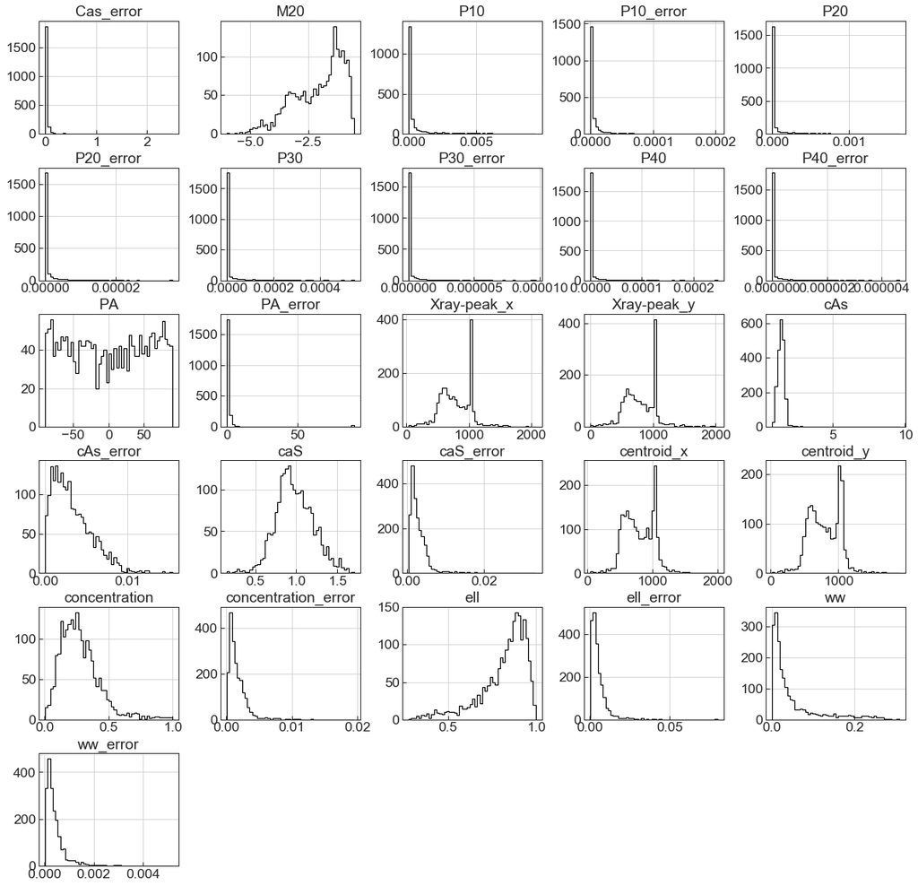

```python
#morphological parameter distributions
plt.rc('text', usetex=False)
morph_parms.hist(bins=50, figsize=(20,20), histtype="step",color='k', linewidth=1.2);
plt.savefig(fig_dir / 'param_dists.pdf',bbox_inches='tight')
plt.show()
```

```python
# replacing the core-excised luminosity with the evolution-scaled core-excised luminosity
#WMAP 7 parameters
omega_l = 0.728
omega_m = 0.272
h=0.704

def E(z):
    return np.sqrt((1+z)**3 * omega_m + omega_l)

magneticum_data['excised_Lx_ergs'] = magneticum_data['excised_Lx_ergs'] * E(magneticum_data['redshift'])**(-7./3.)
#from self-similar scaling
```

```python
#generate the relevant logged categories: mass, Lx, power ratios
magneticum_data['logM500'] = np.log10(magneticum_data['M500_msolh'])
magneticum_data['logLx_ex'] = np.log10(magneticum_data['excised_Lx_ergs'])
magneticum_data['logLx'] = np.log10(magneticum_data['Lx_ergs'])
magneticum_data['logPR10'] = np.log10(magneticum_data['P10'])
magneticum_data['logPR20'] = np.log10(magneticum_data['P20'])
magneticum_data['logPR30'] = np.log10(magneticum_data['P30'])
magneticum_data['logPR40'] = np.log10(magneticum_data['P40'])
magneticum_data['logw'] = np.log10(magneticum_data['ww'])
#magneticum_data['logdxc'] = np.log10(magneticum_data['centroid_xr_dist'])

if(compare_dists):
    morph_parms_erosita['logPR10'] = np.log10(morph_parms_erosita['P10'])
    morph_parms_erosita['logPR20'] = np.log10(morph_parms_erosita['P20'])
    morph_parms_erosita['logPR30'] = np.log10(morph_parms_erosita['P30'])
    morph_parms_erosita['logPR40'] = np.log10(morph_parms_erosita['P40'])
    morph_parms_erosita['logw'] = np.log10(morph_parms_erosita['ww'])
```

### Identifying clusters for visualization

```python
# look at fixed redshift for the clusters with the highest and lowest concentration
sset = magneticum_data[mag_redshifts == 0.1] # largest, brightest because closest
sset = sset[np.logical_and(sset['logM500'] > 14.3, sset['logM500'] < 14.6)]
large_c = np.argsort(sset['concentration'].values)[-1]
small_c = np.argsort(sset['concentration'].values)[0]
print(sset['concentration'].iloc[large_c]); print(sset.iloc[large_c])
print(sset['concentration'].iloc[small_c]); print(sset.iloc[small_c])
```

```
0.369735
uid              77.000000
logM500          14.303947
logLx_ex         -0.203277
logPR10          -5.222111
logPR20          -6.505403
logPR30          -7.060084
logPR40          -7.833478
concentration     0.369735
M20              -2.963320
cAs               1.137670
caS               0.764396
logw             -2.268123
ell               0.915906
PA              -12.060900
Name: 871048, dtype: float64
0.0398168
uid               5.000000
logM500          14.365770
logLx_ex          0.166214
logPR10          -2.724933
logPR20          -3.901252
logPR30          -4.819092
logPR40          -5.488852
concentration     0.039817
M20              -0.632538
cAs               1.004240
caS               0.769381
logw             -0.754410
ell               0.738908
PA              -26.030100
Name: 870976, dtype: float64
```

```python
# look at fixed redshift for the clusters with high and low asymmetry
sset = magneticum_data[mag_redshifts == 0.1] # largest, brightest because closest
sset = sset[np.logical_and(sset['logM500'] > 14.3, sset['logM500'] < 14.6)]
large_A = np.argsort(sset['cAs'].values)[-2]
small_A = np.argsort(sset['cAs'].values)[1]
print(sset['cAs'].iloc[large_A]); print(sset.iloc[large_A])
print(sset['cAs'].iloc[small_A]); print(sset.iloc[small_A])
```

```
1.49215
uid              79.000000
logM500          14.395650
logLx_ex          0.213598
logPR10          -3.374188
logPR20          -5.129577
logPR30          -6.657789
logPR40          -9.317689
concentration     0.136936
M20              -1.117380
cAs               1.492150
caS               0.687391
logw             -1.115400
ell               0.882767
PA              -85.172400
Name: 871050, dtype: float64
0.927353
uid              20.000000
logM500          14.570021
logLx_ex          0.333451
logPR10          -5.763490
logPR20          -6.850938
logPR30          -8.013210
logPR40          -7.986181
concentration     0.294440
M20              -2.595430
cAs               0.927353
caS               0.634942
logw             -2.960304
ell               0.926775
PA               35.278700
Name: 870991, dtype: float64
```

```python
# look at fixed redshift for the clusters with high and low smoothness
sset = magneticum_data[mag_redshifts == 0.1] # largest, brightest because closest
sset = sset[np.logical_and(sset['logM500'] > 14.3, sset['logM500'] < 14.6)]
large_S = np.argsort(sset['caS'].values)[-1]
small_S = np.argsort(sset['caS'].values)[1]
print(sset['caS'].iloc[large_S]); print(sset.iloc[large_S])
print(sset['caS'].iloc[small_S]); print(sset.iloc[small_S])
```

```
1.03454
uid              14.000000
logM500          14.392017
logLx_ex         -0.043696
logPR10          -3.665852
logPR20          -4.516939
logPR30          -5.897659
logPR40          -6.681613
concentration     0.140221
M20              -1.131110
cAs               1.525400
caS               1.034540
logw             -1.280149
ell               0.706221
PA              -49.912800
Name: 870985, dtype: float64
0.612777
uid              26.000000
logM500          14.584378
logLx_ex          0.470066
logPR10          -3.603994
logPR20          -5.545915
logPR30          -7.397938
logPR40          -7.722173
concentration     0.186478
M20              -1.598920
cAs               1.308810
caS               0.612777
logw             -1.265692
ell               0.903630
PA               85.793100
Name: 870997, dtype: float64
```

## Parameter correlations and distributions

```python
corr_matrix = magneticum_data.corr()
corr_matrix['M500_msolh'].sort_values(ascending=False)
```

```
M500_msolh             1.000000
Y500c                  0.987067
T_kev                  0.966411
r500_kpch              0.953490
logM500                0.921856
logLx_ex               0.865394
logLx                  0.856714
R500_deg               0.738098
gas_frac               0.702650
R500_pixel             0.629572
centroid_y             0.479676
centroid_x             0.474409
Xray-peak_x            0.435193
Xray-peak_y            0.426490
excised_Lx_ergs        0.399853
Lx_ergs                0.362307
snapnum                0.233231
snap_id                0.233231
ell                    0.054673
z                      0.047101
x_pixel                0.042696
x                      0.042696
y                      0.038989
M20                    0.036961
vy                     0.015343
cshift                 0.011184
i_sector              -0.019123
vz                    -0.025742
y_pixel               -0.038988
PA                    -0.044183
                         ...
concentration         -0.094800
P40                   -0.096195
M_sat_M_cD            -0.103621
vx                    -0.104422
P30                   -0.107247
ww                    -0.114377
P20                   -0.121475
logPR30               -0.132481
Cas_error             -0.132819
logPR20               -0.136990
logPR40               -0.140508
P10                   -0.141088
logPR10               -0.161001
P40_error             -0.163809
P30_error             -0.174836
P20_error             -0.191388
P10_error             -0.226082
Dcomoving_Mpch        -0.234371
redshift              -0.235105
star_frac             -0.289308
cAs                   -0.297530
ell_error             -0.322504
caS_error             -0.369410
ww_error              -0.371089
Tobs                  -0.382938
concentration_error   -0.393879
caS                   -0.470406
cAs_error             -0.473419
uid                   -0.638710
simRan                      NaN
Name: M500_msolh, Length: 62, dtype: float64
```

```python
#decide whether or not to throw out redshift?

#ALSO THROWING OUT LX AND REDSHIFT

#need to make sure this lines up with the tex columns
cats_to_keep = ['uid', 'logM500', 'logLx_ex', 'logPR10', 'logPR20', 'logPR30', 'logPR40',
                'concentration', 'M20', 'cAs', 'caS', 'logw', 'ell', 'PA']
if(compare_dists):
    cats_to_keep_erosita = ['logPR10', 'logPR20', 'logPR30', 'logPR40',
                            'concentration', 'M20', 'cAs', 'caS', 'logw', 'ell', 'PA']
train_columns_tex = pd.Index([r'Excised $L_x$', r'$\log{P_{10}}$', r'$\log{P_{20}}$', r'$\log{P_{30}}$',
                              r'$\log{P_{40}}$', '$c$', r'$M_{20}$', r'$A$', r'$S$', r'$\log{w}$',
                              r'$e$', r'$\eta$'])
#TODO: Make this a dictionary so there are no issues with indices being mismatched

mag_redshifts = magneticum_data['redshift']

#only keep the categories from above
magneticum_data = magneticum_data[cats_to_keep]
```

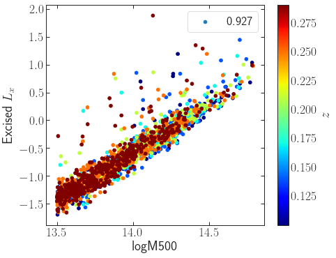

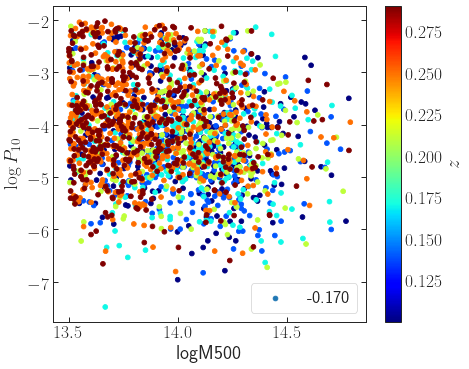

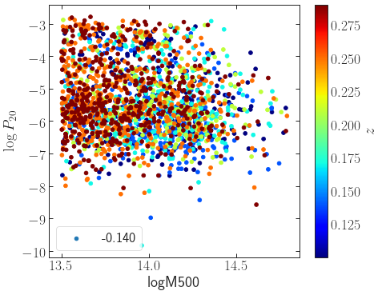

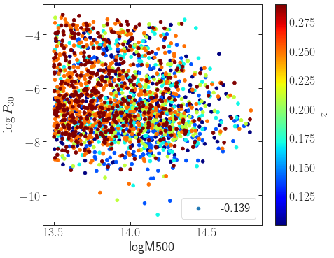

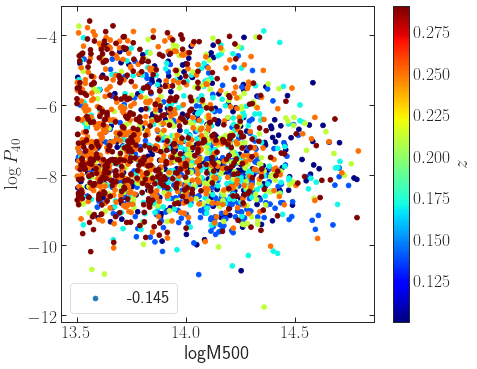

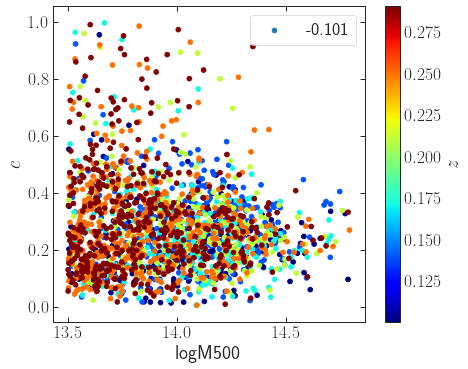

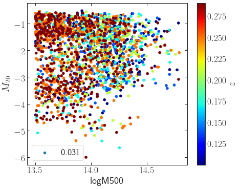

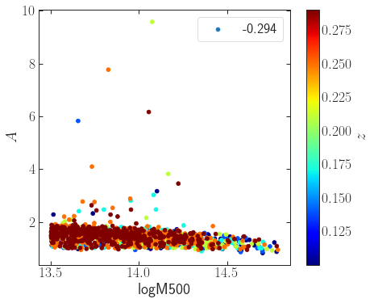

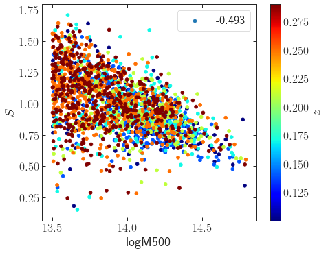

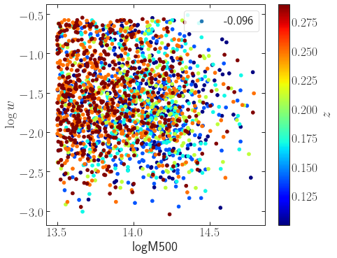

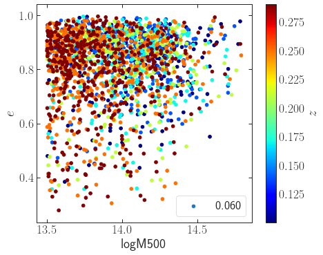

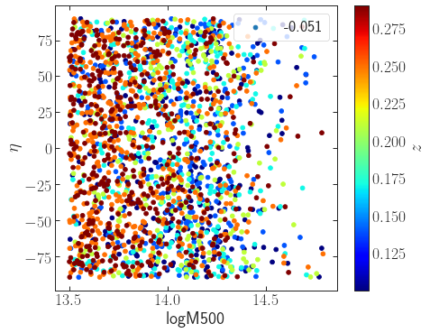

```python
if(compare_dists):
    for i in range(3, len(cats_to_keep)):
        fig, ax = plot()
        cr = np.corrcoef(magneticum_data['logM500'], magneticum_data[cats_to_keep[i]])
        sc = ax.scatter(magneticum_data['logM500'], magneticum_data[cats_to_keep[i]], color='k', s=3, label = 'Chandra')
        ax.scatter(magneticum_data['logM500'], morph_parms_erosita[cats_to_keep_erosita[i-3]], color='r', s=3, label='eROSITA')
        plt.xlabel('logM500')
        plt.ylabel(train_columns_tex[i-2])
        plt.legend()
        if(cats_to_keep[i] == 'cAs'):
            plt.savefig(fig_dir / ('corr_plots/ce_compare_asymmetry.png'))
        else:
            plt.savefig(fig_dir / ('corr_plots/ce_compare_%s.png' % cats_to_keep[i]))
else:
    for i in range(2, len(cats_to_keep)):
        fig, ax = plot()
        cr = np.corrcoef(magneticum_data['logM500'], magneticum_data[cats_to_keep[i]])
        sc = ax.scatter(magneticum_data['logM500'], magneticum_data[cats_to_keep[i]], c=mag_redshifts, cmap=plt.get_cmap('jet'), label = '%0.3f' % cr[0,1])
        cbar = plt.colorbar(sc)
        cbar.set_label(r'$z$')
        plt.xlabel('logM500')
        plt.ylabel(train_columns_tex[i-2])
        plt.legend()
        if(cats_to_keep[i] == 'cAs'):
            plt.savefig(fig_dir / ('corr_plots/asymmetry.png'))
        else:
            plt.savefig(fig_dir / ('corr_plots/%s.png' % cats_to_keep[i]))

# could do the same thing for only one redshift if interested

# NOTE: If we end up including these correlation plots in the final paper, we will want to crop them to disregard
# the one to two outliers that are present in any of them
```

```python
lin_reg = LinearRegression()
lin_reg.fit(magneticum_data['logLx_ex'].values.reshape(-1,1), magneticum_data['logM500'])
predictions = lin_reg.predict(magneticum_data['logLx_ex'].values.reshape(-1,1))
resids = predictions - magneticum_data['logM500'] #pred minus true
mg_dat_v2 = magneticum_data.copy()
mg_dat_v2['resids'] = resids
corr_matrix = mg_dat_v2.corr()
print(corr_matrix['logM500'].sort_values(ascending=True))
print(corr_matrix['resids'].sort_values(ascending=True))
#the mass itself correlates strongly with residual, which means that it's not unbiased
#expect this to go down once we get a truly flat mass function
```

```
uid             -0.830016
caS             -0.492595
resids          -0.374784
cAs             -0.294406
logPR10         -0.169641
logPR40         -0.145402
logPR20         -0.139609
logPR30         -0.139366
concentration   -0.100798
logw            -0.095648
PA              -0.050849
M20              0.031500
ell              0.059797
logLx_ex         0.927112
logM500          1.000000
Name: logM500, dtype: float64
logM500         -3.747840e-01
ell             -1.052764e-01
concentration   -4.117560e-02
logLx_ex        -4.182946e-16
PA               7.297377e-04
cAs              3.416491e-02
caS              4.835258e-02
M20              1.161831e-01
logPR30          1.456677e-01
logPR40          1.491964e-01
logPR20          1.550417e-01
logw             1.950763e-01
logPR10          2.115483e-01
uid              3.388415e-01
resids           1.000000e+00
Name: resids, dtype: float64
```

[figure not shown]

```python
#print distributions of parameters that will be used in analysis
if(compare_dists):
    plt.rc('text', usetex=False)
    ax = magneticum_data.drop(columns=['logM500','logLx_ex','uid']).hist(bins=50, figsize=(20,20), histtype="step",color='k', linewidth=1.2, label='Chandra', density='normed');
    ax = morph_parms_erosita[cats_to_keep_erosita].hist(bins=50, histtype="step",color='r', linewidth=1.2, ax=ax.reshape((12,-1))[0:11], label='eROSITA', density='normed');
    ax[0].legend(loc=2)
    plt.savefig(fig_dir / 'ce_compare_feature_dists.pdf',bbox_inches='tight')
    plt.show()
else:
    plt.rc('text', usetex=False)
    magneticum_data.hist(bins=50, figsize=(20,20), histtype="step",color='k', linewidth=1.2);
    plt.savefig(fig_dir / 'feature_dists.pdf',bbox_inches='tight')
    plt.show()
```

## Train-Test Splitting, Validation, Feature Standardization

```python
#generate train and test set based on uids to keep same cluster across snapshots in either train or test
train_set, test_set = split_train_test_by_id(magneticum_data, test_ratio=0.2, id_column='uid')
print(train_set.shape, test_set.shape)

#let's make copies of the relevant parts of the train and test sets
train = train_set.drop(['logM500', 'uid'], axis=1)
train_columns = train.columns
train_labels = train_set['logM500']
train_uids = train_set['uid']

#store the redshifts of the test set so we can look at scatter binned by redshift
test_redshifts = mag_redshifts.loc[test_set.index] ##MAKE SURE THIS IS CORRECT

test = test_set.drop(['logM500', 'uid'], axis=1)
test_labels = test_set['logM500']

#Generate groups on the train set for group k-fold CV (s.t. each uid halo is only in one group)
n_folds = 10
fold = train_uids % n_folds
logo_iter = list(LeaveOneGroupOut().split(train,train_labels,fold))
```

```
(1615, 14) (426, 14)
```

```
 Fold	 0	 1	 2	 3	 4	 5	 6	 7	 8	 9
 Count	 165	 159	 185	 130	 158	 152	 153	 174	 177	 162
```

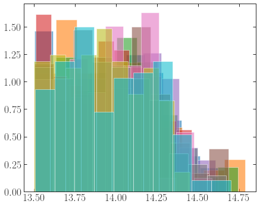

```python
fig,ax = plot()

print("\n Fold\t", end=" ")
for i in range(0,n_folds):
    print(str(i)+'\t', end =" ")
print("\n Count\t", end=" ")
for i in range(0, n_folds):
    print(str(list(fold).count(i))+'\t', end=" ")
    plt.hist(train_labels[fold == i], density='normed', alpha=0.6)
```

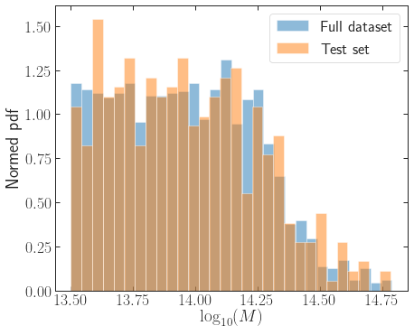

```python
fig, ax = plot()
plt.hist(magneticum_data['logM500'],30,alpha=0.5, density='normed',label='Full dataset')
plt.hist(test_set['logM500'],30,alpha=0.5, density='normed', label='Test set')
plt.legend()
plt.xlabel(r'$\log_{10}(M)$')
plt.ylabel('Normed pdf');
#is this an unbiased enough sample?
```

```python
#scale columns of train set based on median and 16/84 quanties, scale test set by same numbers
if(scale_features):
    rs = RobustScaler(quantile_range=(16.0, 84.0))
    train = rs.fit_transform(train)
    test = rs.transform(test)
else:
    train = train.values
    test  = test.values

# we will need to make the scales for the parameters publicly available if we release the model
```

```python
# save everything needed so cross-validation can be performed on Grace
np.savez(data_dir / 'chandra_training_data_and_folds',logo_iter=logo_iter, train=train, train_labels=train_labels)
```

## Recursive Feature Elimination

[output not shown]

[figure not shown]

```python
#RFE
#TODO: try RandomForestRegression() instead
reg_alg = LinearRegression()

rfe = RFE(reg_alg,1,1)
rfe.fit(train, train_labels)
rnk = rfe.ranking_
print(train_columns[rfe.support_])
print(rfe.ranking_)

print(train_columns[np.argsort(rnk)])

r2_vals = []

for i in range(1, len(train_columns)+1):
    rfe = RFE(reg_alg,i,1)
    rfe.fit(train, train_labels)
    r2_vals.extend([rfe.score(train, train_labels)])

fig, ax = plot(figsize=(10,5))
plt.plot(range(1,len(train_columns)+1), r2_vals)
plt.xlabel('Number of features')
plt.ylabel(r'$r^2$')

ax2 = ax.twiny()
ax2.set_xlim(ax.get_xlim())
ax2.set_xticks(range(1,len(train_columns)+1));
ax2.set_xticklabels(train_columns_tex[np.argsort(rnk)]);
plt.xticks(rotation=50)
#plt.savefig('rfe.pdf',bbox_inches='tight')
```

```python
#code to remove non-important features from our listing
if(use_rfe):
    n_features_to_keep = 10
    reg_alg = LinearRegression()

    rfe = RFE(reg_alg,n_features_to_keep,1)
    rfe.fit(train, train_labels)
    train = train[:,rfe.support_]
    train_columns = train_columns[rfe.support_]
    test = test[:,rfe.support_]
```

## Model fitting and testing

### Part 1: $M-L_x$ Relationship

TODO: Generate list of Maughan curves and plot scatter distribution like in Ntampaka et al. 2018

TODO: Try different cost functions for minimization instead of mean squared error.

```python
#let's get the final number for a simple mass-Lx regression on the training data used to predict the test data
#NOTE: we have not yet introduced redshift dependence here, as is done in Maughan
lin_reg = LinearRegression()
lin_reg.fit(train[:,train_columns == 'logLx_ex'], train_labels)
test_predictions = lin_reg.predict(test[:,train_columns == 'logLx_ex'])
train_predictions = lin_reg.predict(train[:, train_columns == 'logLx_ex'])
m_lx_scatter_robust, m_lx_sc_rb_2sig = scatter_prelog(test_predictions, test_labels)
m_lx_scatter_std = scatter_prelog(test_predictions, test_labels, False)
print("The (robust) scatter for a simple mass-luminosity relationship is %.3f dex" % m_lx_scatter_robust)
print("Robust 2-sigma scatter: %.3f dex" % m_lx_sc_rb_2sig)
print("The (std) scatter for a simple mass-luminosity relationship is %.3f dex" % m_lx_scatter_std)

#the 0.103 is consistent with the 0.11 that probably comes about due to having the extra 300 clusters
```

```
The (robust) scatter for a simple mass-luminosity relationship is 0.081 dex
Robust 2-sigma scatter: 0.177 dex
The (std) scatter for a simple mass-luminosity relationship is 0.102 dex
```

```python
#somehow, the connection between the power ratio and the dxc is important...
#however, with power ratio, dxc, and redshift, we can get it with 0.014 dex... what's going on with that?
#doesn't seem believable... should we throw z out?

#logdxc and logPR10 combined are better than Lx as a tracer for mass... strange...
#very odd that once we add in redshift, we get extremely low scatter though, need to figure that out
```

### Part 2: Ordinary Linear Regression

```python
lin_reg = LinearRegression()
lin_reg.fit(train, train_labels)
test_predictions = lin_reg.predict(test)
lin_reg_scatter_robust, lin_reg_sc_rb_2sig = scatter_prelog(test_predictions, test_labels)
lin_reg_scatter_std = scatter_prelog(test_predictions, test_labels, False)
print("The (robust) scatter for a LR model is %.3f dex" % lin_reg_scatter_robust)
print("Robust 2-sigma scatter: %.3f dex" % lin_reg_sc_rb_2sig)
print("The (std) scatter for a LR model is %.3f dex" % lin_reg_scatter_std)

#TODO: we need to quantify how this changes once we only use the n most important parameters
#TODO: do a plot similar to RFE, but which shows the *scatter* as a function of features remaining
```

```
The (robust) scatter for a LR model is 0.078 dex
Robust 2-sigma scatter: 0.162 dex
The (std) scatter for a LR model is 0.096 dex
```

### Bugfixing d_xc, PR10, z relationship

```python
train_columns
```

[output not shown]

```python
#pick the relevant columns
train_columns[[1,5,12]]
```

[output not shown]

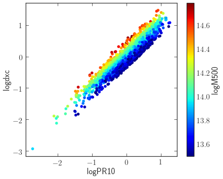

```python
fig,ax = plot()
sc = plt.scatter(train[:,1], train[:,5], c=train_labels, cmap=plt.get_cmap('jet'))
plt.xlabel(train_columns[1])
plt.ylabel(train_columns[5]);
cbar = plt.colorbar(sc);
cbar.set_label(r'logM500');
```

[output not shown]

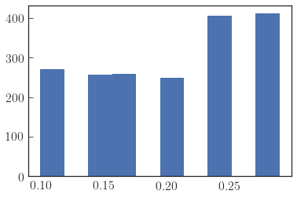

```python
plt.hist(train[:,14])
print(np.unique(train[:,14]))
#what's going on with the redshift?
#something is changing it between up there and down here
```

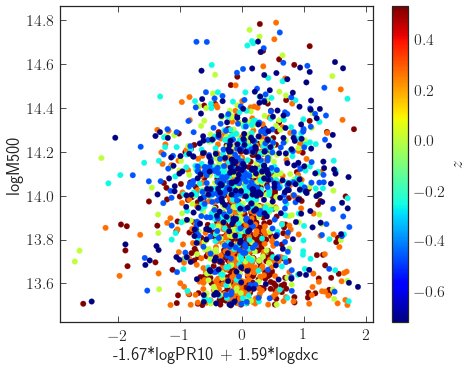

```python
fig,ax = plot()

sc = plt.scatter(-1.13841608* train[:,2] + 2.27764029*train[:,6], train_labels, c=train[:,14], cmap=plt.get_cmap('jet'))
plt.xlabel('-1.67*logPR10 + 1.59*logdxc')
plt.ylabel(r'logM500');
cbar = plt.colorbar(sc);
cbar.set_label(r'$z$');
```

```python
np.corrcoef(train[:,6],train[:,2])
```

```
array([[1.        , 0.99668346],
       [0.99668346, 1.        ]])
```

```python
lin_reg = LinearRegression()
lin_reg.fit(train[:,[2,6,14]], train_labels)
test_predictions = lin_reg.predict(test[:,[2,6,14]])
lin_reg_scatter_robust, lin_reg_sc_rb_2sig = scatter_prelog(test_predictions, test_labels)
lin_reg_scatter_std = scatter_prelog(test_predictions, test_labels, False)
print("The (robust) scatter for a LR model is %.3f dex" % lin_reg_scatter_robust)
print("Robust 2-sigma scatter: %.3f dex" % lin_reg_sc_rb_2sig)
print("The (std) scatter for a LR model is %.3f dex" % lin_reg_scatter_std)
print(lin_reg.coef_, lin_reg.intercept_)
```

```
The (robust) scatter for a LR model is 0.272 dex
Robust 2-sigma scatter: 0.490 dex
The (std) scatter for a LR model is 0.260 dex
[-1.91285776  1.91992107  0.00520935] 13.961221431090676
```

```python
lin_reg = LinearRegression()
lin_reg.fit(train[:,[6,14]], train_labels)
test_predictions = lin_reg.predict(test[:,[6,14]])
lin_reg_scatter_robust, lin_reg_sc_rb_2sig = scatter_prelog(test_predictions, test_labels)
lin_reg_scatter_std = scatter_prelog(test_predictions, test_labels, False)
print("The (robust) scatter for a LR model is %.3f dex" % lin_reg_scatter_robust)
print("Robust 2-sigma scatter: %.3f dex" % lin_reg_sc_rb_2sig)
print("The (std) scatter for a LR model is %.3f dex" % lin_reg_scatter_std)
print(lin_reg.coef_, lin_reg.intercept_)
```

```
The (robust) scatter for a LR model is 0.267 dex
Robust 2-sigma scatter: 0.512 dex
The (std) scatter for a LR model is 0.264 dex
[ 0.02905641 -0.1732834 ] 13.959048711224785
```

```python
lin_reg = LinearRegression()
lin_reg.fit(train[:,[2,14]], train_labels)
test_predictions = lin_reg.predict(test[:,[2,14]])
lin_reg_scatter_robust, lin_reg_sc_rb_2sig = scatter_prelog(test_predictions, test_labels)
lin_reg_scatter_std = scatter_prelog(test_predictions, test_labels, False)
print("The (robust) scatter for a LR model is %.3f dex" % lin_reg_scatter_robust)
print("Robust 2-sigma scatter: %.3f dex" % lin_reg_sc_rb_2sig)
print("The (std) scatter for a LR model is %.3f dex" % lin_reg_scatter_std)
print(lin_reg.coef_, lin_reg.intercept_)
```

```
The (robust) scatter for a LR model is 0.267 dex
Robust 2-sigma scatter: 0.512 dex
The (std) scatter for a LR model is 0.264 dex
[ 0.02740767 -0.17574731] 13.959052904578535
```

```python
lin_reg = LinearRegression()
lin_reg.fit(train[:,[2,6]], train_labels)
test_predictions = lin_reg.predict(test[:,[2,6]])
lin_reg_scatter_robust, lin_reg_sc_rb_2sig = scatter_prelog(test_predictions, test_labels)
lin_reg_scatter_std = scatter_prelog(test_predictions, test_labels, False)
print("The (robust) scatter for a LR model is %.3f dex" % lin_reg_scatter_robust)
print("Robust 2-sigma scatter: %.3f dex" % lin_reg_sc_rb_2sig)
print("The (std) scatter for a LR model is %.3f dex" % lin_reg_scatter_std)
print(lin_reg.coef_, lin_reg.intercept_)
```

```
The (robust) scatter for a LR model is 0.271 dex
Robust 2-sigma scatter: 0.490 dex
The (std) scatter for a LR model is 0.260 dex
[-1.86554426  1.87317572] 13.96114152525596
```

```python
#### BUGFIXING ####
# Let's try this with different combinations of dxc, PR10, and z to figure out how the correlation is so good
# Let's also make sure that it isn't the scatter being low but overall completely biased
```

[figure not shown]

```python
fig,ax=plot()
plt.plot(test_predictions, test_labels, '.')
#it's basically a perfect prediction all the way down...
```

### Part 3: Ridge Regression

```python
#k-fold CV
rr = Ridge()
param_grid = [{'alpha': np.logspace(-4,5,50)}]
grid_search = GridSearchCV(rr, param_grid,
                           cv=logo_iter, scoring='neg_mean_squared_error')
grid_search.fit(train, train_labels)
print(grid_search.best_params_)
best_alpha_rr = grid_search.best_params_['alpha']

#train and test final optimized model
rr = Ridge(alpha=best_alpha_rr)
rr.fit(train, train_labels)
rr_preds = rr.predict(test)
rr_scatter_robust, rr_sc_rb_2sig = scatter_prelog(rr_preds, test_labels)
rr_scatter_std = scatter_prelog(rr_preds, test_labels, False)
print("The (robust) scatter for a RR model is %.3f dex" % rr_scatter_robust)
print("Robust 2-sigma scatter: %.3f dex" % rr_sc_rb_2sig)
print("The (std) scatter for a RR model is %.3f dex" % rr_scatter_std)
```

```
{'alpha': 1.67683293681101}
The (robust) scatter for a RR model is 0.078 dex
Robust 2-sigma scatter: 0.162 dex
The (std) scatter for a RR model is 0.096 dex
```

### Part 4: Lasso Regression

```python
#k-fold CV
lr = Lasso()
param_grid = [{'alpha': np.logspace(-8,5,50)}]
grid_search = GridSearchCV(lr, param_grid,
                           cv=logo_iter, scoring='neg_mean_squared_error')
grid_search.fit(train, train_labels)
print(grid_search.best_params_)
best_alpha_lr = grid_search.best_params_['alpha']

#train and test final optimized model
lr = Lasso(alpha=best_alpha_lr)
lr.fit(train, train_labels)
lr_preds = lr.predict(test)
lr_scatter_robust, lr_sc_rb_2sig = scatter_prelog(lr_preds, test_labels)
lr_scatter_std = scatter_prelog(lr_preds, test_labels, False)
print("The (robust) scatter for a LR model is %.3f dex" % lr_scatter_robust)
print("Robust 2-sigma scatter: %.3f dex" % lr_sc_rb_2sig)
print("The (std) scatter for a LR model is %.3f dex" % lr_scatter_std)
```

```
{'alpha': 0.00032374575428176466}
The (robust) scatter for a LR model is 0.079 dex
Robust 2-sigma scatter: 0.158 dex
The (std) scatter for a LR model is 0.096 dex
```

### Part 5: Random Forest Regression

```python
#randomized search CV for optimizing RF hyperparameters
#NOTE: this takes a long time to run, so will re-run it again once we have final feature sets and data
#notes on cross-validation: https://machinelearningmastery.com/train-final-machine-learning-model/
rf = RandomForestRegressor()
# Number of trees in random forest
n_estimators = [int(x) for x in np.linspace(start = 1000, stop = 2000, num = 6)] # more is better for avoiding overfitting
# Number of features to consider at every split
max_features = ['auto', 'sqrt'] # problem specific
# Maximum number of levels in tree
max_depth = [int(x) for x in np.linspace(10, 110, num = 11)] # large max_depth is ok for RF, but small max_depth for GB
max_depth.append(None)
# Minimum number of samples required to split a node
min_samples_split = [2, 3, 5, 7, 10] # larger value here is better for avoiding overfitting
# Minimum number of samples required at each leaf node
min_samples_leaf = [1, 2, 4, 8] # larger value is better for avoiding overfitting
# Method of selecting samples for training each tree
bootstrap = [True, False]

# Create the random grid
random_grid = {'n_estimators': n_estimators,
               'max_features': max_features,
               'max_depth': max_depth,
               'min_samples_split': min_samples_split,
               'min_samples_leaf': min_samples_leaf,
               'bootstrap': bootstrap}
```

```python
#run the randomized search
if(run_rf_cv):
    rand_search = RandomizedSearchCV(estimator = rf, param_distributions = random_grid, n_iter = 100,
                                 cv = logo_iter, verbose=2, random_state=42, n_jobs = -1,
                                 scoring='neg_mean_squared_error')
    rand_search.fit(train, train_labels)
    rf_params = rand_search.best_params_
    best_model = rand_search.best_estimator_
    print(rand_search.best_params_)
    best_params = rand_search.best_params_
else:
    if(idealized):
        print()
    else:
        # same best parameters using the Chandra data
        # now, are there more parameters that we could optimize?
        best_params = {'n_estimators': 1600, 'min_samples_split': 2, 'min_samples_leaf': 2, 'max_features': 'auto', 'max_depth': 60, 'bootstrap': True}
#TODO: after we run randomized search on our full dataset,
#try narrowing down one more step with an additional grid search
```

```
Fitting 10 folds for each of 100 candidates, totalling 1000 fits
```

```
[Parallel(n_jobs=-1)]: Using backend LokyBackend with 8 concurrent workers.
[Parallel(n_jobs=-1)]: Done  25 tasks      | elapsed:   13.0s
[Parallel(n_jobs=-1)]: Done 146 tasks      | elapsed:  3.4min
[Parallel(n_jobs=-1)]: Done 349 tasks      | elapsed:  8.4min
[Parallel(n_jobs=-1)]: Done 632 tasks      | elapsed: 13.2min
[Parallel(n_jobs=-1)]: Done 1000 out of 1000 | elapsed: 31.3min finished
```

```
{'n_estimators': 1200, 'min_samples_split': 2, 'min_samples_leaf': 4, 'max_features': 'auto', 'max_depth': 50, 'bootstrap': True}
```

```python
#if(idealized):
#    print()
#else:
#    best_params = {'n_estimators': 1600, 'min_samples_split': 2, 'min_samples_leaf': 2, 'max_features': 'auto', 'max_depth': 60, 'bootstrap': True}

# now, let's do a grid-search CV
#rf = RandomForestRegressor(random_state=42)
#param_grid = [{'n_estimators': [1500,1600,1700], 'min_samples_split':[2,3,4], 'min_samples_leaf':[1,2,3],'max_features':['auto','sqrt'], 'max_depth':[50,60,70], 'bootstrap':[True,False]}]
#grid_search = GridSearchCV(rf, param_grid, n_jobs=-1,
#                           cv=logo_iter, scoring='neg_mean_squared_error')
#grid_search.fit(train, train_labels)
#print(grid_search.best_params_)
```

```python
#RF without cross-validation, default hyperparameters
rf = RandomForestRegressor(random_state=42)

rf.fit(train, train_labels)
rf_preds = rf.predict(test)
rf_scatter_robust, rf_sc_rb_2sig = scatter_prelog(rf_preds, test_labels)
rf_scatter_std = scatter_prelog(rf_preds, test_labels, False)
print("The (robust) scatter for a RF model is %.3f dex" % rf_scatter_robust)
print("Robust 2-sigma scatter: %.3f dex" % rf_sc_rb_2sig)
print("The (std) scatter for a RF model is %.3f dex" % rf_scatter_std)
```

```
The (robust) scatter for a RF model is 0.070 dex
Robust 2-sigma scatter: 0.159 dex
The (std) scatter for a RF model is 0.088 dex
```

```python
rf = RandomForestRegressor(random_state=42, bootstrap=False, max_depth=50, max_features=0.5, min_samples_leaf=2,
                           min_samples_split=2, n_estimators=1000)

#{'bootstrap': False, 'min_samples_leaf': 2, 'n_estimators': 1000, 'min_samples_split': 2, 'max_features': 0.5, 'max_depth': 50}

# let's play a bit with max features to see if something in between 3 and 12 is good
print(np.mean(cross_val_score(rf, train, train_labels, cv=logo_iter, scoring='neg_mean_squared_error')))

# current best parameters: -0.0071652676657399435
# best parameters with max_features=0.5: -0.006762182586815648 (this is close to the gradient boosted regressor one)
# best parameters with max_features=0.75: -0.0068384746423482915
# NOTE: the cross-validation error is actually reduced considerably more in our best fit
# reduced min_samples_leaf to 1, keep max_features=0.5: -0.006736532845819686
```

```
-0.006701490983837261
```

```python
#use the best set of hyperparameters to train RF model on whole train set, test on test set
#TODO: go back and do RFE using RF since we have an idea of the hyperparameter values
#rf = RandomForestRegressor(random_state=42, bootstrap=True, max_depth=90, max_features='auto', min_samples_leaf=2,
#                           min_samples_split=2, n_estimators=2000)
#rf = RandomForestRegressor(random_state=42, bootstrap=True, max_depth=50, max_features='auto', min_samples_leaf=2,
#                           min_samples_split=2, n_estimators=1600)
rf = RandomForestRegressor(random_state=42, bootstrap=False, max_depth=50, max_features=0.5, min_samples_leaf=2,
                           min_samples_split=2, n_estimators=1000)

rf.fit(train, train_labels)
rf_preds = rf.predict(test)
rf_scatter_robust, rf_sc_rb_2sig = scatter_prelog(rf_preds, test_labels)
rf_scatter_std = scatter_prelog(rf_preds, test_labels, False)
print("The (robust) scatter for a RF model is %.5f dex" % rf_scatter_robust)
print("Robust 2-sigma scatter: %.3f dex" % rf_sc_rb_2sig)
print("The (std) scatter for a RF model is %.5f dex" % rf_scatter_std)
#no optimization, 4.5% scatter on the test set...
#now we can use grid-search CV on the train set to get the best value
#10.2% scatter if we just use logLx_ex
#still 4.5% scatter on test set if we use the cross-validated model
#going from 8.9 to 5% scatter is a pretty solid reduction, and this is with only 7 features... what about all?
#only a slight change depending on if we use 7 features or all (4.8 vs 4.5% scatter)
#if we use all features, cross-validated, we get 4.5% scatter!!!
#If we replace cshift with my centroid-xray peak distance in physical units, we get !!3.4% scatter with bias -0.002
#4.43% scatter with best_estimator_
#when we include redshift and my centroid-xray peak distance we get 2.8% scatter with bias of -0.0011
#if we then also add the non-core-excised value, we get scatter of 2.7% w/ bias -0.0021

#model is greatly improved if we log the necessary columns

# so if we use neg mean sq error as the metric for cross-validation, we get 0.067/0.084 for robust/std
# if we use robust_scatter as scoring: same exact values; it doesn't matter!
# hence, it is strange that gradient boosting trees does another 6% better
```

```
The (robust) scatter for a RF model is 0.06613 dex
Robust 2-sigma scatter: 0.157 dex
The (std) scatter for a RF model is 0.08511 dex
```

```python
#look at feature importance for RF
for i in range(0,len(train_columns)):
    print('%.4f \t %s' % (rf.feature_importances_[i], train_columns[i]))
```

```
0.7486 	 logLx_ex
0.0100 	 logPR10
0.0058 	 logPR20
0.0067 	 logPR30
0.0062 	 logPR40
0.0385 	 concentration
0.0144 	 M20
0.0475 	 cAs
0.1000 	 caS
0.0084 	 logw
0.0076 	 ell
0.0064 	 PA
```

```python
#calculate RF model performance (bias from mean vs. median?)
evaluate(rf, test, test_labels)
robust_bias = np.median(rf_preds - test_labels)
bias = np.mean(rf_preds - test_labels)
print('The final RF model applied to test set had a (robust) bias of %.4f dex' % robust_bias)
print('The final RF model applied to test set had a bias of %.4f dex' % bias)
```

```
Model Performance
Average Error: 0.0593 dex.
Accuracy = 99.58%.
The final RF model applied to test set had a (robust) bias of -0.0040 dex
The final RF model applied to test set had a bias of -0.0050 dex
```

## Results, Plots, Scatter distributions, etc.

We need to copy over the mass-luminosity plots from the other Jupyter notebook to see how our results look with eROSITA vs. Chandra.

```
[13.4 13.6 13.8 14.  14.2 14.4 14.6 14.8]
The predicted-to-true intercept is 1.365
The predicted-to-true slope is 0.902
High masses will be underpredicted!
```

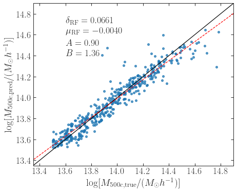

```python
#compare RF predicted masses to true

fig, ax = plot()
plt.plot(test_labels, rf_preds, '.', markersize=8, alpha=0.75)
plt.xlabel(r'$\log[M_{500c,\mathrm{true}} / (M_\odot h^{-1})]$');
plt.ylabel(r'$\log[M_{500c,\mathrm{pred}} / (M_\odot h^{-1})]$');
plt.plot([12,16], [12,16], 'k')

#see how close to 1-1 the predictions are, i.e., what is the slope?
lin_reg = LinearRegression()
lin_reg.fit(test_labels.values.reshape(-1,1), rf_preds)

#should add the scatter and the regression fit
plt.text(13.6,14.7,r'$\delta_\mathrm{RF} = %.4f$' % rf_scatter_robust, fontsize=18)
plt.text(13.6,14.6,r'$\mu_\mathrm{RF} = %.4f$' % robust_bias, fontsize=18)
plt.text(13.6,14.5,r'$A = %.2f$' % lin_reg.coef_[0], fontsize=18)
plt.text(13.6,14.4,r'$B = %.2f$' % lin_reg.intercept_, fontsize=18)

xv = np.linspace(12, 16, 50)
plt.plot(xv, xv*lin_reg.coef_[0] + lin_reg.intercept_, 'r', linestyle='dashed')

plt.xlim(13.35, 14.9)
plt.ylim(13.35, 14.9)

# Set major ticks for x axis
ticks = np.linspace(13.4, 14.8, 8)
print(ticks)

ax.set_xticks(ticks)
ax.set_yticks(ticks)

print("The predicted-to-true intercept is %.3f" % lin_reg.intercept_)
print("The predicted-to-true slope is %.3f" % lin_reg.coef_[0])
if(lin_reg.coef_[0] < 1):
    print("High masses will be underpredicted!")
else:
    print("High masses will be overpredicted!")

plt.savefig(fig_dir / 'mpred_vs_mtrue.pdf', bbox_inches='tight')

#TODO: figure out what is going on with the outliers

#could perhaps do the intercept in terms of M_14 or something so that the zero point has more meaning..
```

```python
lin_reg = LinearRegression()
lin_reg.fit(train[:,train_columns == 'logLx_ex'], train_labels)
mlx_predictions = lin_reg.predict(test[:,train_columns == 'logLx_ex'])
#train_predictions = lin_reg.predict(train[:, train_columns == 'logLx_ex'])
m_lx_scatter_robust, m_lx_sc_rb_2sig = scatter_prelog(mlx_predictions, test_labels)
m_lx_scatter_std = scatter_prelog(mlx_predictions, test_labels, False)
print("The (robust) scatter for a simple mass-luminosity relationship is %.3f dex" % m_lx_scatter_robust)
print("Robust 2-sigma scatter: %.3f dex" % m_lx_sc_rb_2sig)
print("The (std) scatter for a simple mass-luminosity relationship is %.3f dex" % m_lx_scatter_std)
```

```
The (robust) scatter for a simple mass-luminosity relationship is 0.081 dex
Robust 2-sigma scatter: 0.177 dex
The (std) scatter for a simple mass-luminosity relationship is 0.102 dex
```

```python
rf_preds_systematic = np.load('rf_preds_systematic.npy')
rf_scatter_systematic_robust, junk = scatter_prelog(rf_preds_systematic,test_labels)
```

[output not shown]

[output cut: 8 more lines]

[output not shown]

[figure not shown]

```python
#look at distribution of residuals for final RF model, for idealized and non, and for m-lx baseline
fig, ax = plot()
plt.hist(rf_preds - test_labels, histtype='step', color='k', linestyle='solid',
         linewidth=2, bins=30, density="normed", label='RF Ideal \n %.3f dex,\n %.2f percent' %(rf_scatter_robust,(10**rf_scatter_robust - 1)*100)) #change this to the actual %age
#plt.hist(rf_preds_systematic - test_labels, histtype='step', color='r', linestyle='dashdot',
#         linewidth=2, bins=30, density="normed", label='RF Systematic \n %.3f dex,\n %.2f percent' %(rf_scatter_systematic_robust,(10**rf_scatter_systematic_robust - 1)*100))
plt.hist(mlx_predictions - test_labels, histtype='step', color='b', linestyle='dashed',
         linewidth=2, bins=30, density="normed", label='$M-L_{\mathrm{ex}}(z)$ \n %.3f dex,\n %.2f percent' %(m_lx_scatter_robust,(10**m_lx_scatter_robust - 1)*100))
plt.xlabel(r'$\log(M_{500c,\mathrm{pred}}) - \log(M_{500c,\mathrm{true}})$')
plt.ylabel('PDF');
plt.legend()

# slightly less biased perhaps, let's report on the biases between the various ones?

#over-plot mass-luminosity relationship?

plt.savefig(fig_dir / 'error_dist.pdf', bbox_inches='tight')

# there is roughly an 18% improvement regardless of which scatter definition we use...
```

### Redshift dependence on scatter

Not really worth looking at

[output not shown]

[figure not shown]

```python
#scatter as a function of redshift

fig, ax = plot()

z,c = np.unique(test_redshifts, return_counts=True)
#for this, we need to actually go back and get the redshifts, since they were dropped from the dataset
for i,z in enumerate(np.unique(test_redshifts)):
    rfs, rf2 = scatter_prelog(rf_preds[test_redshifts == z], test_labels[test_redshifts == z])
    print(z,rfs,c[i])
    plt.hist(rf_preds[test_redshifts == z] - test_labels[test_redshifts == z], histtype='step',
         linewidth=1.2, bins=30, density="normed", label=r'$z$=%.2f, %.3f dex' %(z,rfs)) #change this to the actual %age

plt.xlabel(r'$\log(M_{500c,\textrm{pred}}) - \log(M_{500c,\textrm{true}})$')
plt.ylabel('PDF');
plt.legend()
plt.savefig(fig_dir / 'error_dist_redshift.pdf', bbox_inches='tight')
```

## Generating Images of Clusters

```python
if(instrument == 'chandra'):
    center_lower = 1035
    center_upper = 1035
elif(instrument == 'erosita'):
    center_lower = 191
    center_upper = 192

clusterlist = np.load(data_dir / (instrument+'_clusterList.npy'))
```

```python
def gen_plot(cluster_id, vmin=None, vmax=None):
    head = fits.open(use_dir / ('%d.fits' % cluster_id))
    data = fits.open(use_dir / ('%d.fits' % cluster_id))[0].data

    print(np.sum(data))

    masked_array = np.log10(np.ma.array (data, mask=(data==0)));
    cmap = cm.plasma
    cmap.set_bad('black',1.)
    fig, ax = plot(figsize=(10,10))
    ax.imshow(masked_array, interpolation='nearest', extent=[0,1,0,1], cmap=cmap, origin='lower', vmin=vmin, vmax=vmax)
    plt.axis('off')
    rad = clusterlist['R500_pixel'][clusterlist['id'] == cluster_id]
    #plt.xlim(center_lower-rad,center_upper+rad)
    #plt.ylim(center_lower-rad,center_upper+rad)
    return fig,ax

def photon_count(cluster_id):
    head = fits.open(use_dir / ('%d.fits' % cluster_id))
    data = fits.open(use_dir / ('%d.fits' % cluster_id))[0].data

    return np.sum(data)
```

### Verifying photon count distributions

```python
ranked_by_mass = magneticum_data.sort_values(by='logM500').index
photon_counts = np.zeros(len(ranked_by_mass))
for i in range(0, len(ranked_by_mass)):
    print(i)
    photon_counts[i] = photon_count(ranked_by_mass[i])
```

[output not shown]

[output cut: 1986 more lines]

[output not shown]

```python
uz = np.unique(mag_redshifts)
```

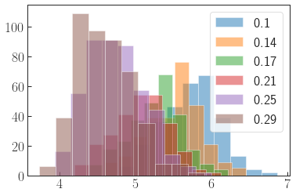

```python
zs = mag_redshifts.loc[ranked_by_mass]
for i in range(0,len(uz)):
    plt.hist(np.log10(photon_counts[zs == uz[i]]), alpha=0.5, label=uz[i])
plt.legend()

# there don't seem to be any outliers now
```